# Report making extravaganza

Ana Bento

February 25, 2016

## First steps

> Step 1: Install R studio

> Step 2: Need to download the rmarkdown, knitr and pander packages – these are specific to the rmarkdown document making magic

## Creating the rmarkdown script

> 1. Open R studio
> 2. File –> New File –> R markdown –> Create *file name* and choose the *type* of Document HTML, PDF, and MS Word)
> 3. The default anatomy of the document is created, but like most things, it is just the start of the party
> 5. As you build the document, you can **Knit** for previews

# This is the largest heading: you would type “/#Your heading text”

## This is the second largest heading: you would type “/##Your heading text”

### This is the third largest heading: you would type “/###Your heading text”

#### This is the fourth largest heading: you would type “/####Your heading text”

##### This is the fifth largest heading: you would type “/#####Your heading text”

###### This is the sixth largest heading: you would type “/######Dude I totally get this pattern”

Note: The sixth heading is smaller than the normal text.

## Ways to get different text formats

1. For numbered lists you would write “1. The list thing” (no tab in front, but you DO need a space between the period and the text)
   - For a sub-section of the list, you would write “*tab* + The list thing”, with a tab in front and a space between the plus (- or + also works in place of the *)
- For bulleted lists, you can use *, -, or + in (* your thing)
  - For a sub-bullet, you’d use “*tab* - the thing”

For *italics*, you can do *italics* or _italics_. For **bold**, you can do **bold** or _*bold_*.

## Links

To do [links](https://www.rstudio.com/wp-content/uploads/2015/02/rmarkdown-cheatsheet.pdf), you type “[the text] (the URL)” with no space in between.

## Quotes

Let’s quote some stuff:

> “Mathematics without natural history is sterile, but natural history without mathematics is muddled.” *John Maynard Smith*

## Footnotes

This is regular text[^1].

## Formulas and equations

**Example 1**: This summation expression $\sum_{i=1}^n X_i$ appears inline. this equation is also inline $E=mc^2$

**Example 2**:This summation expression is in display form.

$$\sum_{i=1}^n X_i$$

**Example 3**:
$$f(x, \mu, \sigma) = \frac{1}{\sigma\sqrt{2\pi}}e^{-\frac{(x-\mu)^2}{2\sigma^2}}$$

**Example 4**: Numbering the equations

1. $f(x) = \frac{1}{\pi(1+x^2)}$

The Cauchy distribution (with density given in Eq. (1)) is a special case of Student’s $t$-distribution (Eq. (2)) with $\nu = 1$.

2. $$f(t; \nu) = \frac{\Gamma(\frac{\nu+1}{2})} {\sqrt{\nu\pi}\,\Gamma(\frac{\nu}{2})} \left(1+\frac{t^2}{\nu} \right)^{-\frac{\nu+1}{2}}$$

**Example 5**:

3. $$\Gamma(t) = \int^\infty_0 x^{t-1}e^{-x}dx$$

**Example 6**:

4. $$\frac{dx}{dt} = x(\alpha - \beta y)$$
   $$\frac{dy}{dt} = - y(\gamma - \delta x)$$

The system of ordinary differential equations given by Eq. (4) is commonly used to describe predator-prey systems. Any solution to this system of equations satisfies the equality in Eq. (5).

5. $$V = -\delta \, x + \gamma \, \log(x) - \beta \, y + \alpha \, \log(y)$$

## Subscripts and superscripts

**Example 1**:
$$X_i$$
**Example 2**:
$$X_{i}$$
**Example 3**:
$$X^2_{i,j}$$
**Example 4**: To do<sup>superscripts</sup> in text you can also use type^superscript^.

## Square roots

**Example**:
$$\sqrt{b^2 - 4ac}$$

## Fractions

**Example**:
$$\frac{4z^3}{16}$$

## Summation expressions

**Example**:
$$\sum_{i=1}^{n} X^3_i$$

## Parenthesis

**Example**:
$$\sum_{i=1}^{n}\left( \frac{X_i}{Y_i} \right)$$

## Greek Letters

**Example**:
$$\alpha, \beta, \gamma, \Gamma$$

## Special Symbols

**Example 1**:
$$a \pm b$$
**Example 2**:
$$x \ge 15$$
**Example 3**:
$$a_i \ge 0~~~\forall i$$

## Integrals and other functions

**Example**:
$$\int_0^{2\pi} \sin x~dx$$

## Matrices

**Example**:
$$\mathbf{X} = \left[\begin{array}
{rrr}
1 & 2 & 3 \\
4 & 5 & 6 \\
7 & 8 & 9
\end{array}\right]$$

## Making your code easily reproducible by your collaborators

## Chunks of code

If in the middle of our text we need to do analysis or plots, we can insert *R* code can easily using what we called “chunks” of code. You can embed an R code chunk like this:

## Analysis

```r
set.seed(1234)
library(ggplot2)
library(lattice)
library(MASS)
test=rnorm(10000, 1,0.1)
```

## Figures

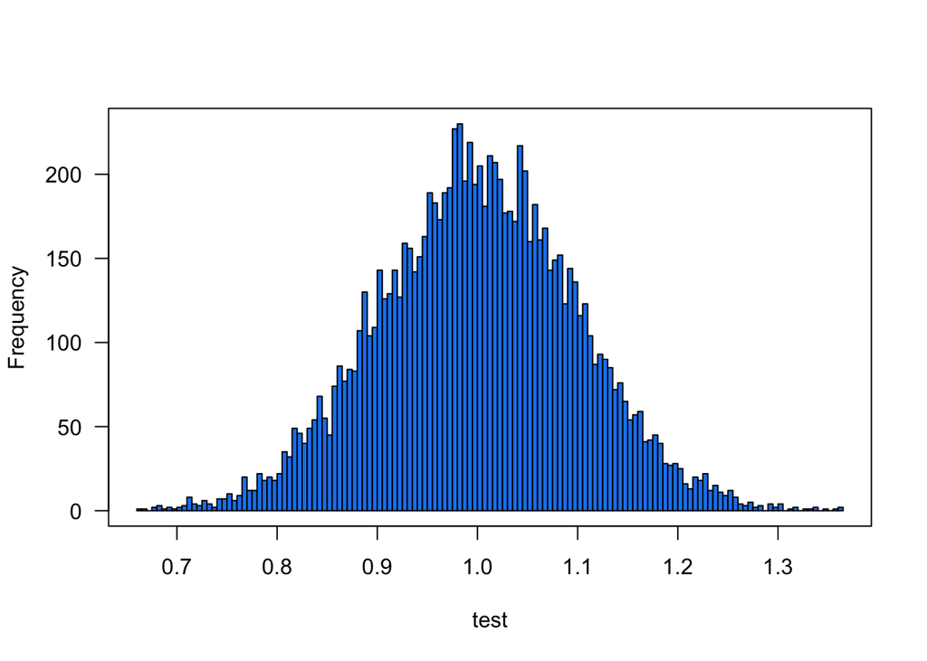

You can change the figure dimensions and add captions

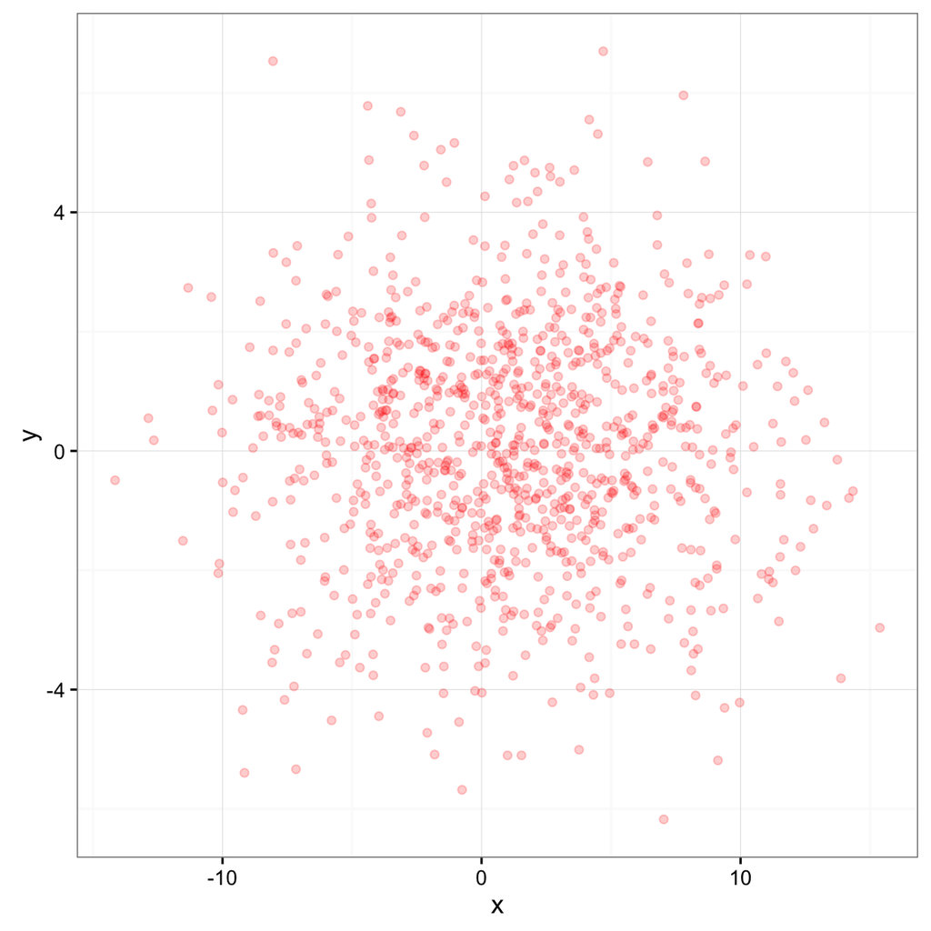

This figure will blow your mind

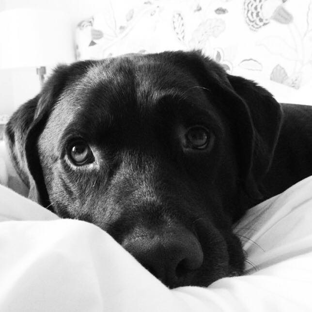

### Control figure size

The following is an example of a smaller figure using `fig.width` and `fig.height` options.

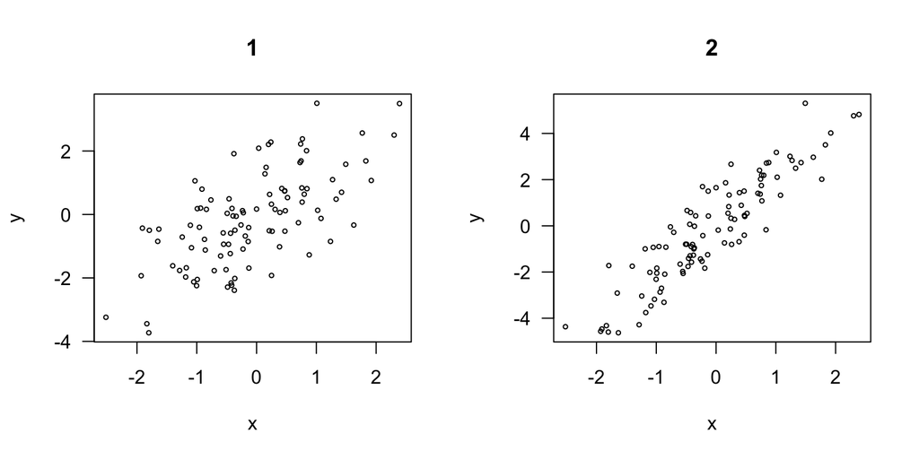

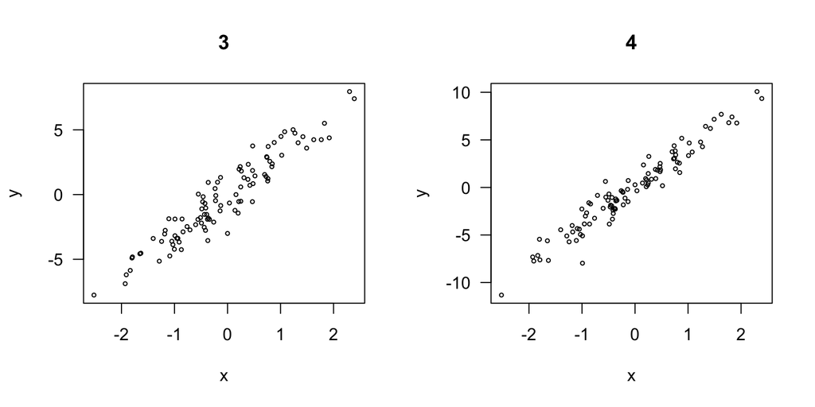

## Tables

Producing an output model as a table

|  | Estimate | Std. Error | t value | Pr(>\|t\|) |
| --- | --- | --- | --- | --- |
| (Intercept) | 0.05 | 0.09 | 0.49 | 0.62 |
| x | 2.04 | 0.08 | 24.13 | 0.00 |

Custom table

| Region | City |
| --- | --- |
| East Midlands | Lincoln |
| East Midlands | Nottingham |
| Eastern | Bedford |
| Eastern | Norwich |

## Using references: what you need

1. A *bib* file with your library or references.
2. A *cls* file that will indicate the journal style for the references. In this [zotero link](https://www.zotero.org/styles) you can find hundreds of styles in *cls* format, that you need to define at the beggining of the rmarkdown document (above I’m using *plos-biology*)

**Example**: A study has shown blah [1]. Campbell [2] has show blah.

## Spaces

Forcing spaces between figures or paragraphs with (“& nbsp;” with no spaces) or leaving a line blank between paragraphs.

Navideh likes frozen yoghurt.

Toby loves bananas.

## References

1. Adams J, Kimball A, Adams F. Early immunization against pertussis. American Journal Dis Child. 1947;74: 10–12.

2. Campbell H, Amirthalingam G, Andrews N. Accelerating control of pertussis in England and Wales. Emerg Infec Dis. 2012;18: 38–47.

[^1]: with a footnote